# DM Group Assignment: Thera Bank - Loan Purchase Modelling

By- Anup Chougule, Rohit Raj Singh, Venkatesh Taduvayi

## Problem Statement

This case is about a bank (Thera Bank) which has a growing customer base. Majority of these customers are liability customers (depositors) with varying size of deposits. The number of customers who are also borrowers (asset customers) is quite small, and the bank is interested in expanding this base rapidly to bring in more loan business and in the process, earn more through the interest on loans. In particular, the management wants to explore ways of converting its liability customers to personal loan customers (while retaining them as depositors). A campaign that the bank ran last year for liability customers showed a healthy conversion rate of over 9% success. This has encouraged the retail marketing department to devise campaigns with better target marketing to increase the success ratio with a minimal budget. The department wants to build a model that will help them identify the potential customers who have a higher probability of purchasing the loan. This will increase the success ratio while at the same time reduce the cost of the campaign. The dataset has data on 5000 customers. The data include customer demographic information (age, income, etc.), the customer's relationship with the bank (mortgage, securities account, etc.), and the customer response to the last personal loan campaign (Personal Loan). Among these 5000 customers, only 480 (= 9.6%) accepted the personal loan that was offered to them in the earlier campaign

You are brought in as a consultant and your job is to build the best model which can classify the right customers who have a higher probability of purchasing the loan. You are expected to do the following: 1. EDA of the data available. Showcase the results using appropriate graphs 2. Apply appropriate clustering on the data and interpret the output 3. Build appropriate models on both the test and train data (CART, Random Forest). Interpret all the model outputs and do the necessary modifications wherever eligible (such as pruning) 4. Check the performance of all the models that you have built (test and train). Use all the model performance measures you have learned so far. Share your remarks on which model performs the best. The solution should be a report with proper explanation, R code, interpretation & Conclusion.

#### Load Loan Purchase Data

```r
LoanP.data = read.csv("C:/BABI/Module5-DataMining/Group-Assignment/Thera Bank-Data Set.csv", header = TRUE)
```

#### Section 1 - a. Basic data summary, Univariate, Bivariate analysis, graphs

#### Data Summary - Str, Summary, Unique Values

```r
str(LoanP.data)
```

```
## 'data.frame':    5000 obs. of  14 variables:
##  $ ID                   : int  1 2 3 4 5 6 7 8 9 10 ...
##  $ Age..in.years.       : int  25 45 39 35 35 37 53 50 35 34 ...
##  $ Experience..in.years.: int  1 19 15 9 8 13 27 24 10 9 ...
##  $ Income..in.K.month.  : int  49 34 11 100 45 29 72 22 81 180 ...
##  $ ZIP.Code             : int  91107 90089 94720 94112 91330 92121 91711 93943 90089 93023 ...
##  $ Family.members       : int  4 3 1 1 4 4 2 1 3 1 ...
##  $ CCAvg                : num  1.6 1.5 1 2.7 1 0.4 1.5 0.3 0.6 8.9 ...
##  $ Education            : int  1 1 1 2 2 2 2 3 2 3 ...
##  $ Mortgage             : int  0 0 0 0 0 155 0 0 104 0 ...
##  $ Personal.Loan        : int  0 0 0 0 0 0 0 0 0 1 ...
##  $ Securities.Account   : int  1 1 0 0 0 0 0 0 0 0 ...
##  $ CD.Account           : int  0 0 0 0 0 0 0 0 0 0 ...
##  $ Online               : int  0 0 0 0 0 1 1 0 1 0 ...
##  $ CreditCard           : int  0 0 0 0 1 0 0 1 0 0 ...
```

```r
sum(complete.cases(LoanP.data))/5000
```

```
## [1] 0.9964
```

```r
apply(LoanP.data, 2, function(x) length(unique(x)))
```

```
##                    ID        Age..in.years. Experience..in.years.
##                  5000                    45                    47
##   Income..in.K.month.              ZIP.Code        Family.members
##                   162                   467                     5
##                 CCAvg             Education              Mortgage
##                   108                     3                   347
##         Personal.Loan    Securities.Account            CD.Account
##                     2                     2                     2
##                Online            CreditCard
##                     2                     2
```

```r
summary(LoanP.data)
```

```
##        ID       Age..in.years.  Experience..in.years. Income..in.K.month.
##  Min.   :   1   Min.   :23.00   Min.   :-3.0          Min.   :  8.00
##  1st Qu.:1251   1st Qu.:35.00   1st Qu.:10.0          1st Qu.: 39.00
##  Median :2500   Median :45.00   Median :20.0          Median : 64.00
##  Mean   :2500   Mean   :45.34   Mean   :20.1          Mean   : 73.77
##  3rd Qu.:3750   3rd Qu.:55.00   3rd Qu.:30.0          3rd Qu.: 98.00
##  Max.   :5000   Max.   :67.00   Max.   :43.0          Max.   :224.00
##
##     ZIP.Code     Family.members      CCAvg          Education
##  Min.   : 9307   Min.   :1.000   Min.   : 0.000   Min.   :1.000
##  1st Qu.:91911   1st Qu.:1.000   1st Qu.: 0.700   1st Qu.:1.000
##  Median :93437   Median :2.000   Median : 1.500   Median :2.000
##  Mean   :93153   Mean   :2.397   Mean   : 1.938   Mean   :1.881
##  3rd Qu.:94608   3rd Qu.:3.000   3rd Qu.: 2.500   3rd Qu.:3.000
##  Max.   :96651   Max.   :4.000   Max.   :10.000   Max.   :3.000
##                  NA's   :18
##     Mortgage     Personal.Loan   Securities.Account   CD.Account
##  Min.   :  0.0   Min.   :0.000   Min.   :0.0000     Min.   :0.0000
##  1st Qu.:  0.0   1st Qu.:0.000   1st Qu.:0.0000     1st Qu.:0.0000
##  Median :  0.0   Median :0.000   Median :0.0000     Median :0.0000
##  Mean   : 56.5   Mean   :0.096   Mean   :0.1044     Mean   :0.0604
##  3rd Qu.:101.0   3rd Qu.:0.000   3rd Qu.:0.0000     3rd Qu.:0.0000
##  Max.   :635.0   Max.   :1.000   Max.   :1.0000     Max.   :1.0000
##
##      Online         CreditCard
##  Min.   :0.0000   Min.   :0.000
##  1st Qu.:0.0000   1st Qu.:0.000
##  Median :1.0000   Median :0.000
##  Mean   :0.5968   Mean   :0.294
##  3rd Qu.:1.0000   3rd Qu.:1.000
##  Max.   :1.0000   Max.   :1.000
##
```

Insights: Data sample has 5000 observations and 14 variables.

The 14 attributes are divided as below - ID - Customer Identification does not add any interesting info. No association with loan, also it does not provide any conclusion for future potential loan customers. This can be ignored for Model prediction.

The binary category have five variables - Personal Loan (Target Variable), Securities Account,CD Account, Online,Credit Card

Interval variables - Age, Experience, Income, CCAvg, Mortage

Ordinal Categorical Variables - Family and Education

The nominal variable - ID and Zip Code

All attrobutes are captured as either Integer or Numeric

Sample dataset has 99% observations has all values. Good population to go-ahead with Modelling

Among these 5000 customers, only 480 (= 9.6%) accepted the personal loan that was offered to them in the earlier campaign

Count of Unique values for each column in Sample Dataset as below:- ID - 5000 , Age..in.years - 45, Experience..in.years - 47 , Income..in.K.month. - 162 ,ZIP.Code - 467 ,Family.members - 5, CCAvg - 108, Education 3, Mortgage - 347, Personal.Loan - 2 , Securities.Account - 2, CD.Account - 2, Online - 2, CreditCard -2

Summary

ID - Running sequence number starting from 1 and ending at 5000 with a Mean of 2500.

Experience..in.years - Experience is normally distributed with more customer having experience starting from 8 years. Here the mean is equal to median. There are negative values in the Experience. This could be a data input error as in general it is not possible to measure negative years of experience. We have two options either delete them or mark them as Zeros. We will go with second option of converting them to zeros.

Family.members - Ranges from 1 to 4 with average of 2.39. We also have null values for 18 customers.We have two options either delete them or mark them as Zero. We will go with second option of converting them to zero.

CCAvg - CCAvg is positively skewed variable and average spending is between 0K to 10K and majority spends less than 2.5K. Average across customers stands at 1.93K.

Mortgage - Mortgage 70% of the individuals have a mortgage of less than 40K. However the max value is 635K

Personal.Loan - only 480 (= 9.6%) accepted the personal loan that was offered to them in the earlier campaign

Securities.Account - 522 customer out of 5000 have securities account with the bank

CD.Account - 302 customers out of 5000 have CD account with the Bank

Online - Around 60% customers (2984 out of 5000) uses online banking facilities.

CreditCard - Around 30% overall customers use credit card issues by the Bank

#### Transformation - Few of the experience in years are Negative make them Zero. Also Family Members Null values to Zero

```r
library(psych)
library(imputeTS)
LoanP.data$Experience..in.years.= ifelse(LoanP.data$Experience..in.years. < 0, 0, LoanP.data$Experience..in.years.)
LoanP.data =na_replace(LoanP.data,0)
sum(complete.cases(LoanP.data))/5000
```

```
## [1] 1
```

```r
LoanPcartrandom.data = LoanP.data
```

#### Univariate Analysis

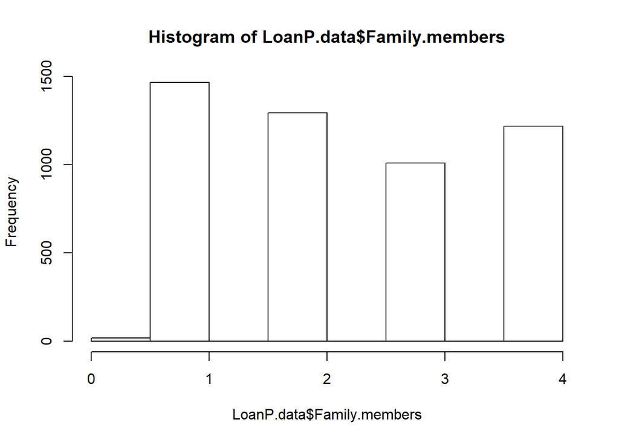

```r
hist(LoanP.data$Family.members)
```

Observation - More then half of the customers either have 1 or 2 family Members

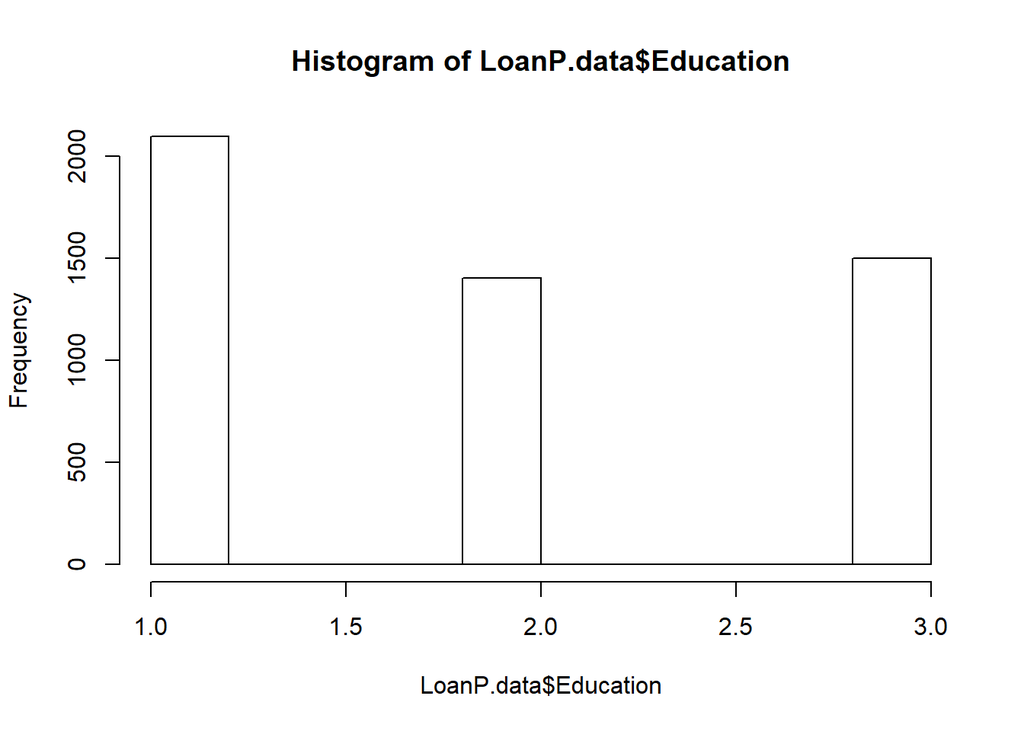

```r
hist(LoanP.data$Education)
```

Observation - Graph shows more or less equal distribution. Customer with Undergrad education are slightly higher

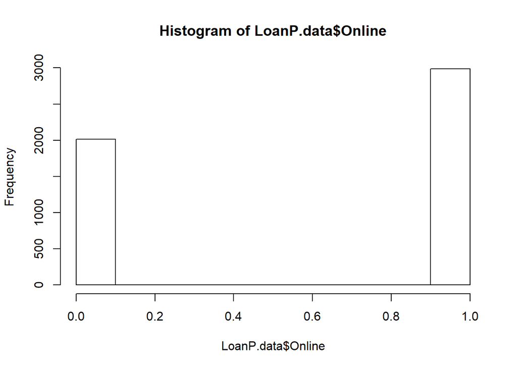

```r
hist(LoanP.data$Online)
```

Observation - Graph shows around 60% of customers use online Internet Banking facilities

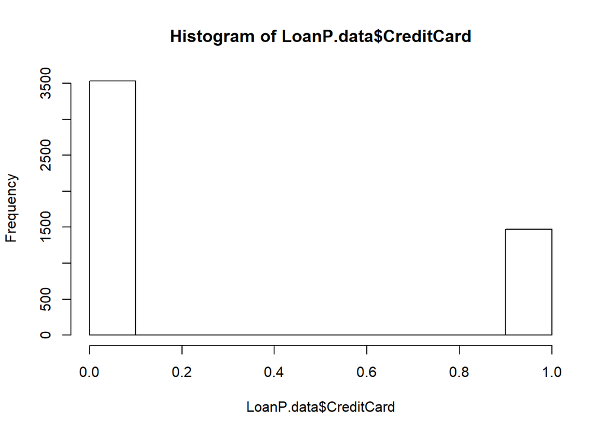

```r
hist(LoanP.data$CreditCard)
```

Observation - Graph shows 70% of the customers does’t use credit card issued by the bank

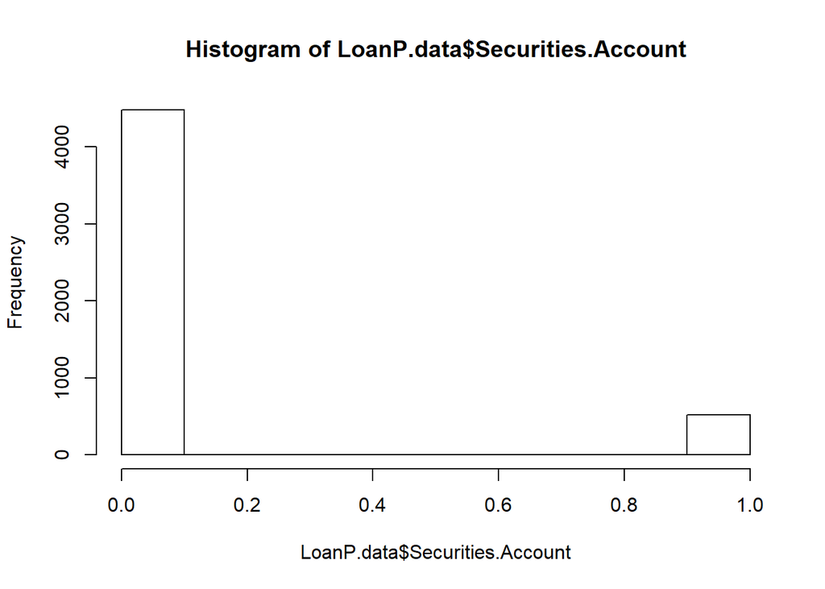

```r
hist(LoanP.data$Securities.Account)
```

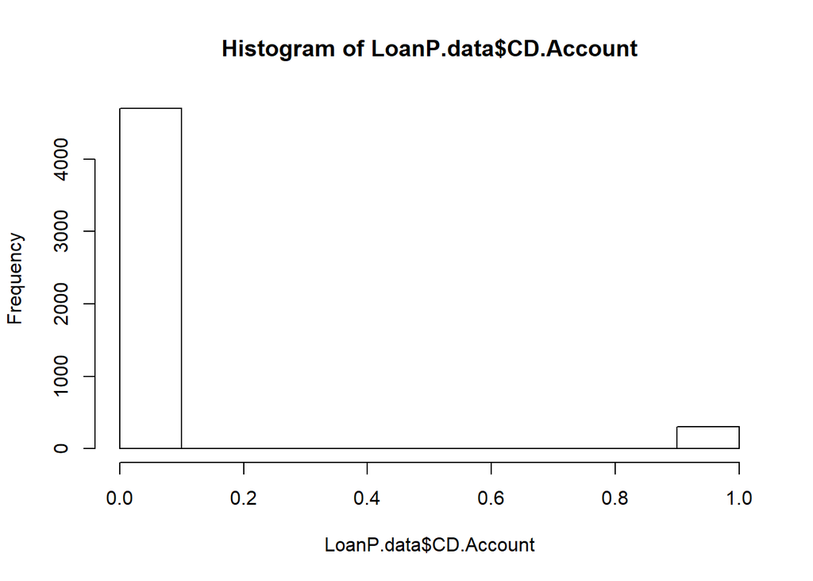

```r
hist(LoanP.data$CD.Account)
```

#### Bivariate Analysis

1. Does Customers income/education affects personal loan outcome

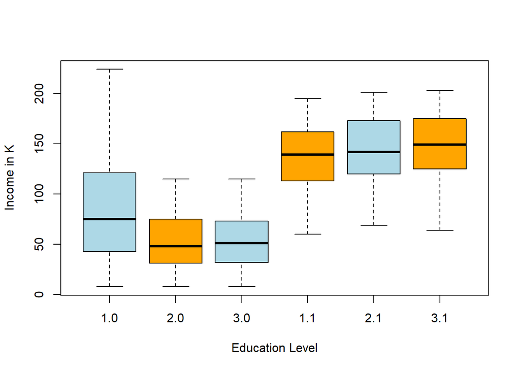

```r
boxplot(LoanP.data$Income..in.K.month. ~ LoanP.data$Education+LoanP.data$Personal.Loan, data=LoanP.data, col=(c("lightblue","orange")), xlab="Education Level", ylab="Income in K" )
```

Observation : It seems the customers whose education level is 1 is having more income. However customers who has taken the personal loan have the same income levels

2. Does Customers Mortgage/education affects personal loan outcome

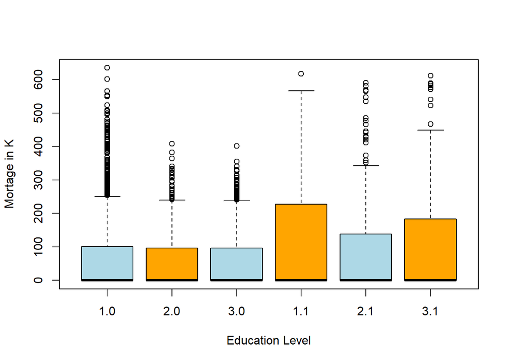

```r
boxplot(LoanP.data$Mortgage ~ LoanP.data$Education+LoanP.data$Personal.Loan, data=LoanP.data, col=(c("lightblue","orange")), xlab="Education Level", ylab="Mortage in K" )
```

Observation : From the above chart it seems that customer who do not have personal loan and customer who has personal loan have high mortgage

3. Securities Account Vs Personal Loan

```r
library(ggplot2)
df = data.frame(LoanP.data$Securities,LoanP.data$Personal.Loan)
df$LoanP.data.Securities = as.factor(df$LoanP.data.Securities)
df$LoanP.data.Personal.Loan = as.factor(df$LoanP.data.Personal.Loan)
str(df)
```

```
## 'data.frame':    5000 obs. of  2 variables:
##  $ LoanP.data.Securities   : Factor w/ 2 levels "0","1": 2 2 1 1 1 1 1 1 1 1 ...
##  $ LoanP.data.Personal.Loan: Factor w/ 2 levels "0","1": 1 1 1 1 1 1 1 1 1 2 ...
```

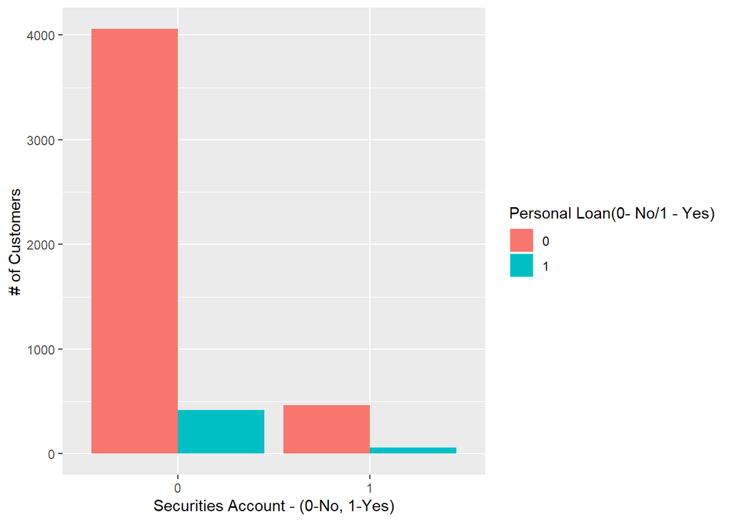

```r
ggplot(df, aes(df$LoanP.data.Securities)) + geom_bar(aes(fill = df$LoanP.data.Personal.Loan), position = "dodge") + ylab("# of Customers") + xlab("Securities Account - (0-No, 1-Yes)") +labs(fill = "Personal Loan(0- No/1 - Yes)")
```

4. Family Members Vs Personal Loan

```r
library(ggplot2)
df = data.frame(LoanP.data$Family.members,LoanP.data$Personal.Loan)
df$LoanP.data.Family.members = as.factor(df$LoanP.data.Family.members)
df$LoanP.data.Personal.Loan = as.factor(df$LoanP.data.Personal.Loan)
str(df)
```

```
## 'data.frame':    5000 obs. of  2 variables:
##  $ LoanP.data.Family.members: Factor w/ 5 levels "0","1","2","3",..: 5 4 2 2 5 5 3 2 4 2 ...
##  $ LoanP.data.Personal.Loan : Factor w/ 2 levels "0","1": 1 1 1 1 1 1 1 1 1 2 ...
```

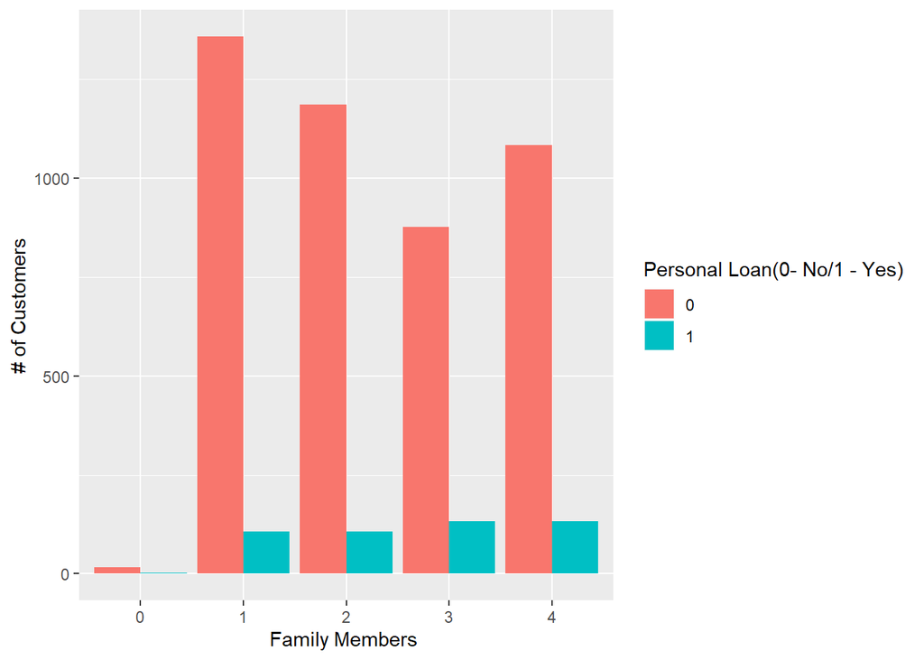

```r
ggplot(df, aes(df$LoanP.data.Family.members)) + geom_bar(aes(fill = df$LoanP.data.Personal.Loan), position = "dodge") + ylab("# of Customers") + xlab("Family Members ") +labs(fill = "Personal Loan(0- No/1 - Yes)")
```

Observation: Family size does not have any impact in personal loan. But it seems families with size of 3 are more likely to take loan. When considering future campaign this might be good association.

5. CD Account Vs Personal Loan

```r
library(ggplot2)
df = data.frame(LoanP.data$CD.Account,LoanP.data$Personal.Loan)
df$LoanP.data.CD.Account = as.factor(df$LoanP.data.CD.Account)
df$LoanP.data.Personal.Loan = as.factor(df$LoanP.data.Personal.Loan)
str(df)
```

```
## 'data.frame':    5000 obs. of  2 variables:
##  $ LoanP.data.CD.Account   : Factor w/ 2 levels "0","1": 1 1 1 1 1 1 1 1 1 1 ...
##  $ LoanP.data.Personal.Loan: Factor w/ 2 levels "0","1": 1 1 1 1 1 1 1 1 1 2 ...
```

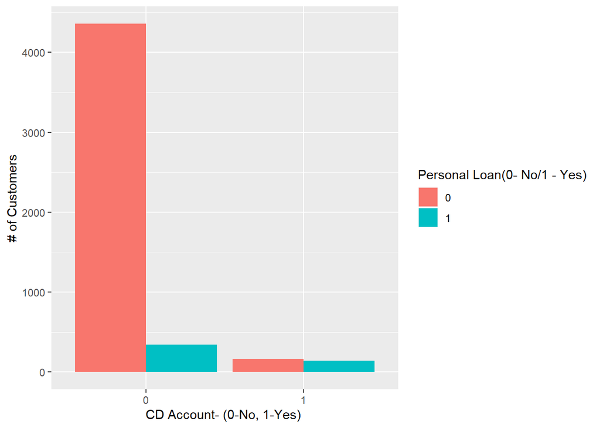

```r
ggplot(df, aes(df$LoanP.data.CD.Account)) + geom_bar(aes(fill = df$LoanP.data.Personal.Loan), position = "dodge") + ylab("# of Customers") + xlab("CD Account- (0-No, 1-Yes) ") +labs(fill = "Personal Loan(0- No/1 - Yes)")
```

6. CC Average Vs Personal Loan

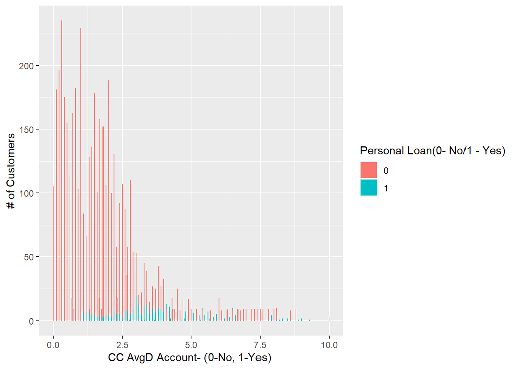

```r
ggplot(df, aes(LoanP.data$CCAvg)) + geom_bar(aes(fill = df$LoanP.data.Personal.Loan)) + ylab("# of Customers") + xlab("CC AvgD Account- (0-No, 1-Yes) ") +labs(fill = "Personal Loan(0- No/1 - Yes)")
```

```r
median(LoanP.data$CCAvg)
```

```
## [1] 1.5
```

```r
median(LoanP.data$CCAvg[LoanP.data$Personal.Loan == 1])
```

```
## [1] 3.8
```

```r
median(LoanP.data$CCAvg[LoanP.data$Personal.Loan == 0])
```

```
## [1] 1.4
```

Observation: Customers opted for personal loan have a higher credit card average. Average credit card spending with a median of 3800 dollar indicates a higher probability of personal loan. Lower credit card spending with a median of 1400 dollars is less likely to take a loan. This could be useful information. (Median for all = 1.5K, Medain for Personal Cust = 3.8K and Medain for Non Personal Loan Cust = 1.4K)

7. Age Vs Personal Loan

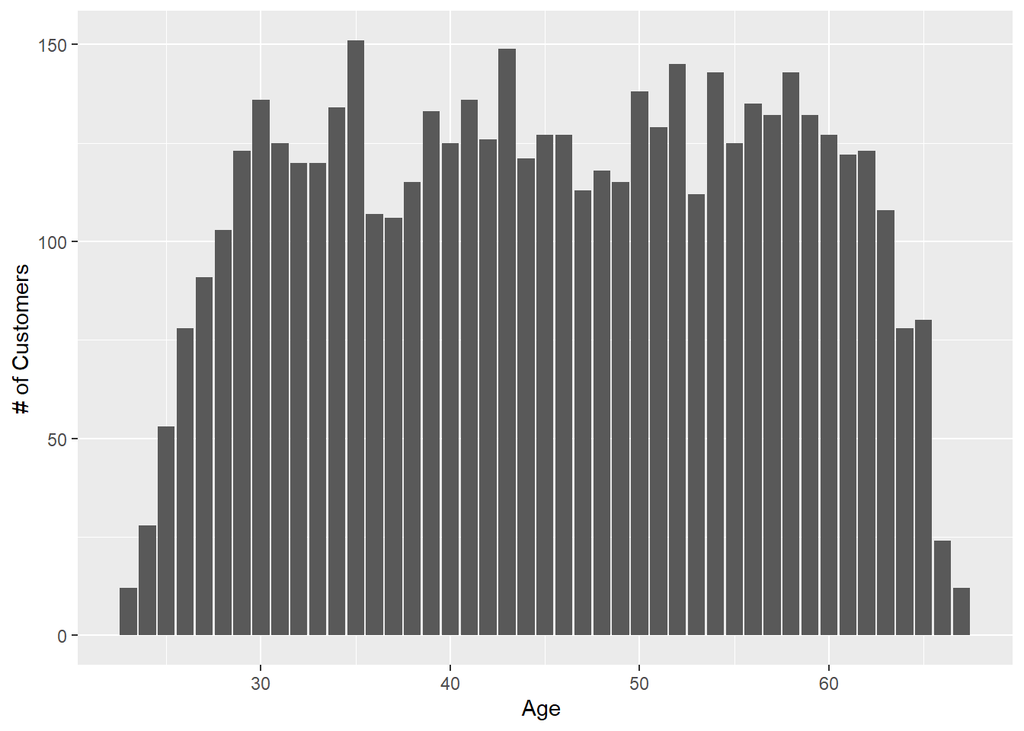

```r
ggplot(LoanP.data, aes(LoanP.data$Age..in.years.)) + geom_bar(aes(fill = LoanP.data$Personal.Loan)) + ylab("# of Customers") + xlab("Age ") +labs(fill = "Personal Loan(0- No/1 - Yes)")
```

Observation: Customers with All Ages opted for Personal Loan

8. Age Vs Experience

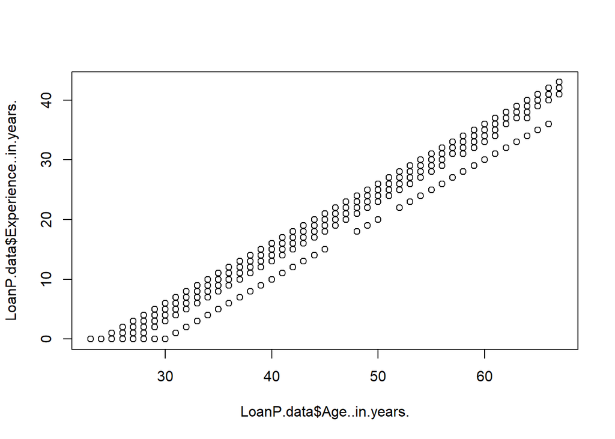

```r
plot(LoanP.data$Age..in.years., LoanP.data$Experience..in.years.)
```

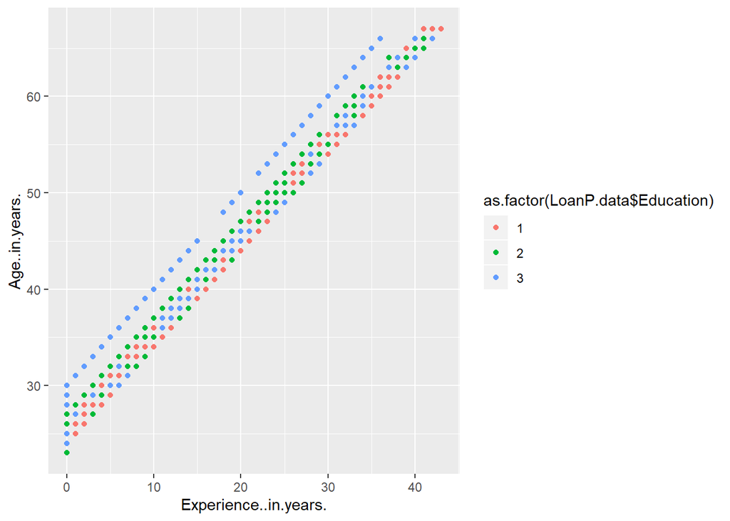

```r
library(ggplot2)
ggplot() + geom_point(data = LoanP.data, aes(x =Experience..in.years. , y = Age..in.years., color = as.factor(LoanP.data$Education)))
```

Observation - Experience and age have a positive correlation. As experience increase age also increases. Also the colors show the education level. There is gap in the mid forties of age and also more people in the under graduate level

9. Family Members Vs Income

```r
df1 = data.frame(LoanP.data$Family.members, LoanP.data$Income..in.K.month., LoanP.data$Personal.Loan)

str(df1)
```

```
## 'data.frame':    5000 obs. of  3 variables:
##  $ LoanP.data.Family.members     : num  4 3 1 1 4 4 2 1 3 1 ...
##  $ LoanP.data.Income..in.K.month.: int  49 34 11 100 45 29 72 22 81 180 ...
##  $ LoanP.data.Personal.Loan      : int  0 0 0 0 0 0 0 0 0 1 ...
```

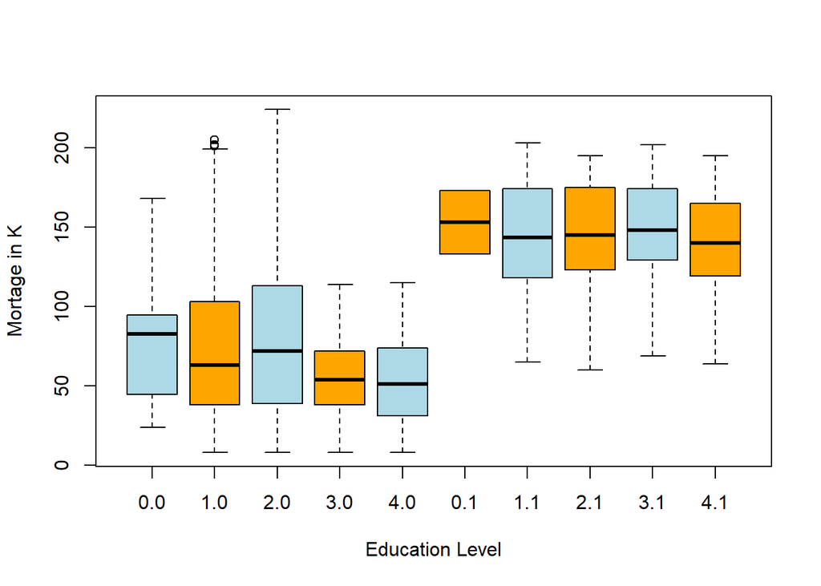

```r
df1$LoanP.data.Family.members = as.factor(df1$LoanP.data.Family.members)

boxplot(df1$LoanP.data.Income..in.K.month. ~ df1$LoanP.data.Family.members+ df1$LoanP.data.Personal.Loan, data=df1, col=(c("lightblue","orange")), xlab="Education Level", ylab="Mortage in K" )
```

Observation - Families with income less than 100K are less likely to take loan,than families with high income

10. Coorelation Among all Variables

```r
Loan.data1 = LoanP.data[,-c(1,5)]
str(Loan.data1)
```

```
## 'data.frame':    5000 obs. of  12 variables:
##  $ Age..in.years.       : int  25 45 39 35 35 37 53 50 35 34 ...
##  $ Experience..in.years.: num  1 19 15 9 8 13 27 24 10 9 ...
##  $ Income..in.K.month.  : int  49 34 11 100 45 29 72 22 81 180 ...
##  $ Family.members       : num  4 3 1 1 4 4 2 1 3 1 ...
##  $ CCAvg                : num  1.6 1.5 1 2.7 1 0.4 1.5 0.3 0.6 8.9 ...
##  $ Education            : int  1 1 1 2 2 2 2 3 2 3 ...
##  $ Mortgage             : int  0 0 0 0 0 155 0 0 104 0 ...
##  $ Personal.Loan        : int  0 0 0 0 0 0 0 0 0 1 ...
##  $ Securities.Account   : int  1 1 0 0 0 0 0 0 0 0 ...
##  $ CD.Account           : int  0 0 0 0 0 0 0 0 0 0 ...
##  $ Online               : int  0 0 0 0 0 1 1 0 1 0 ...
##  $ CreditCard           : int  0 0 0 0 1 0 0 1 0 0 ...
```

```r
corLoandata = cor(Loan.data1)
round(corLoandata,2)
```

```
##                       Age..in.years. Experience..in.years.
## Age..in.years.                  1.00                  0.99
## Experience..in.years.           0.99                  1.00
## Income..in.K.month.            -0.06                 -0.05
## Family.members                 -0.05                 -0.05
## CCAvg                          -0.05                 -0.05
## Education                       0.04                  0.01
## Mortgage                       -0.01                 -0.01
## Personal.Loan                  -0.01                 -0.01
## Securities.Account              0.00                  0.00
## CD.Account                      0.01                  0.01
## Online                          0.01                  0.01
## CreditCard                      0.01                  0.01
##                       Income..in.K.month. Family.members CCAvg Education
## Age..in.years.                      -0.06          -0.05 -0.05      0.04
## Experience..in.years.               -0.05          -0.05 -0.05      0.01
## Income..in.K.month.                  1.00          -0.16  0.65     -0.19
## Family.members                      -0.16           1.00 -0.11      0.06
## CCAvg                                0.65          -0.11  1.00     -0.14
## Education                           -0.19           0.06 -0.14      1.00
## Mortgage                             0.21          -0.02  0.11     -0.03
## Personal.Loan                        0.50           0.06  0.37      0.14
## Securities.Account                   0.00           0.02  0.02     -0.01
## CD.Account                           0.17           0.01  0.14      0.01
## Online                               0.01           0.01  0.00     -0.02
## CreditCard                           0.00           0.01 -0.01     -0.01
##                       Mortgage Personal.Loan Securities.Account CD.Account
## Age..in.years.           -0.01         -0.01               0.00       0.01
## Experience..in.years.    -0.01         -0.01               0.00       0.01
## Income..in.K.month.       0.21          0.50               0.00       0.17
## Family.members           -0.02          0.06               0.02       0.01
## CCAvg                     0.11          0.37               0.02       0.14
## Education                -0.03          0.14              -0.01       0.01
## Mortgage                  1.00          0.14              -0.01       0.09
## Personal.Loan             0.14          1.00               0.02       0.32
## Securities.Account       -0.01          0.02               1.00       0.32
## CD.Account                0.09          0.32               0.32       1.00
## Online                   -0.01          0.01               0.01       0.18
## CreditCard               -0.01          0.00              -0.02       0.28
##                       Online CreditCard
## Age..in.years.          0.01       0.01
## Experience..in.years.   0.01       0.01
## Income..in.K.month.     0.01       0.00
## Family.members          0.01       0.01
## CCAvg                   0.00      -0.01
## Education              -0.02      -0.01
## Mortgage               -0.01      -0.01
## Personal.Loan           0.01       0.00
## Securities.Account      0.01      -0.02
## CD.Account              0.18       0.28
## Online                  1.00       0.00
## CreditCard              0.00       1.00
```

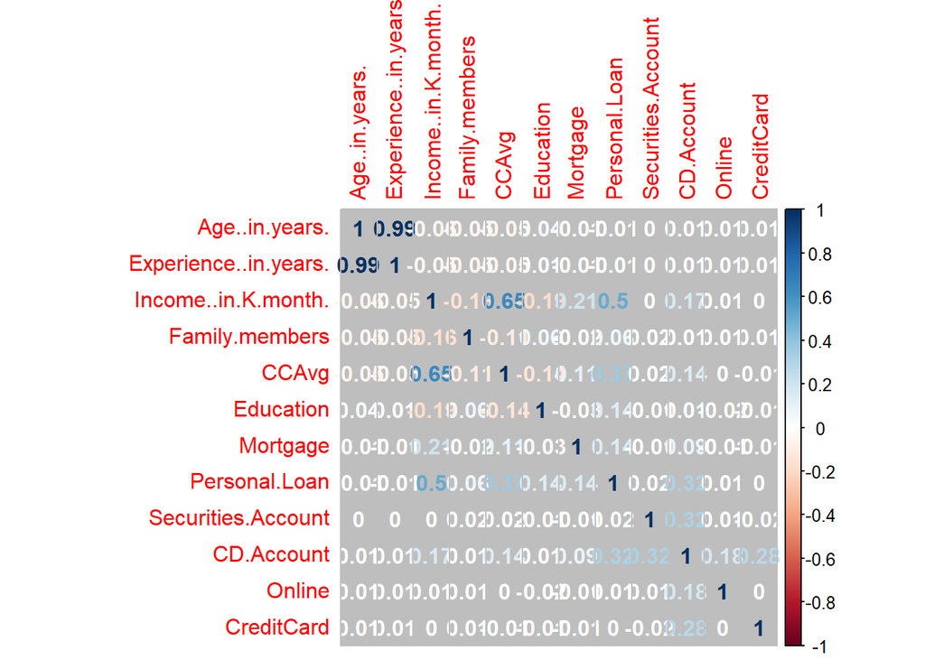

```r
library(corrplot)
corrplot(corLoandata, method= "number", bg = "grey")
```

Observation - Income and CCAvg is moderately correlated. Age and Experience is highly correlated Income and Personal Loan is mildly correlated

11. Coorelation using ggpairs

```r
library("GGally")
```

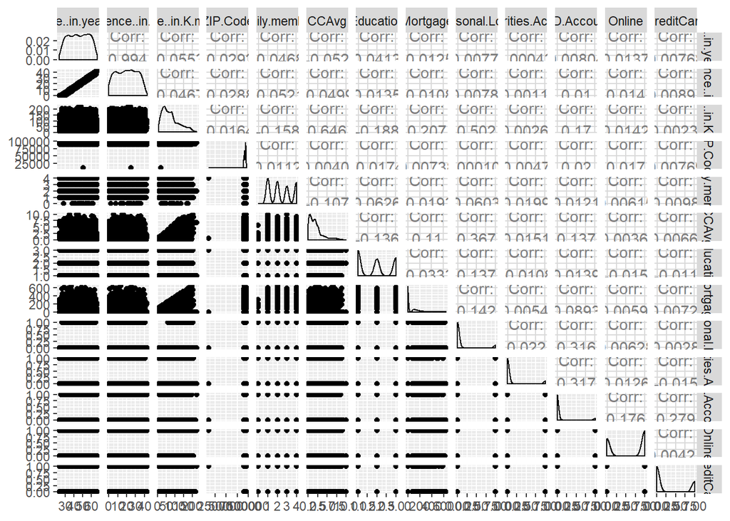

```r
ggpairs(LoanP.data[-1])
```

#### Section 2 - a. Apply Clustering algorithm b. Clustering Output interpretation

1. Apply scaling to get all data elements in one range. Taking out ZIp code from scope as stated in last step.

```r
LoanP.scaled = scale(LoanP.data[,-c(1,5)])
head(LoanP.scaled, 10)
```

```
##       Age..in.years. Experience..in.years. Income..in.K.month.
##  [1,]    -1.77423939           -1.67122301          -0.5381750
##  [2,]    -0.02952064           -0.09786299          -0.8640230
##  [3,]    -0.55293627           -0.44749855          -1.3636566
##  [4,]    -0.90188002           -0.97195189           0.5697084
##  [5,]    -0.90188002           -1.05936078          -0.6250678
##  [6,]    -0.72740814           -0.62231633          -0.9726390
##  [7,]     0.66836686            0.60140813          -0.0385413
##  [8,]     0.40665905            0.33918146          -1.1247014
##  [9,]    -0.90188002           -0.88454300           0.1569675
## [10,]    -0.98911595           -0.97195189           2.3075645
##       Family.members      CCAvg  Education   Mortgage Personal.Loan
##  [1,]      1.3962869 -0.1933661 -1.0489730 -0.5554684    -0.3258427
##  [2,]      0.5297814 -0.2505855 -1.0489730 -0.5554684    -0.3258427
##  [3,]     -1.2032295 -0.5366825 -1.0489730 -0.5554684    -0.3258427
```

[output cut: 18 more lines]

```r
sum(complete.cases(LoanP.scaled))/5000
```

```
## [1] 1
```

2. Clustering Algorithms are broadly classified into two categories i.e. Hierarchical and Partitioning (No Hierarchical).

Hierarchical clustering is characterized by a tree like structure and uses distance as a measure of (dis)similarity. Partitioning (Non Hierarchical) algorithms starts with a set of partitions as clusters and alliteratively refines the partitions to form stable clusters.

We have two types in Hierarchical Clustering. Agglomerative (“Bottom-up”) Start with the points as individual clusters and, at each step, merge the closest pair of clusters.

Divisive (“Top-down”) Start with one, all-inclusive cluster and, at each step, split a cluster until only singleton clusters of individual points remain.

Non hierarchical or portioning clustering is K Means.The major difference here is one needs to provide Number of Clusters as input at the beginning.

We will try both Hierarchical (hclust) and Non Hierarchical (K Means)on Thea dataset and see results before we arrive at conclusion

2.1 Try first with Alglomerative type i.e. Hierarchical Cluster Algorithm Without scaling

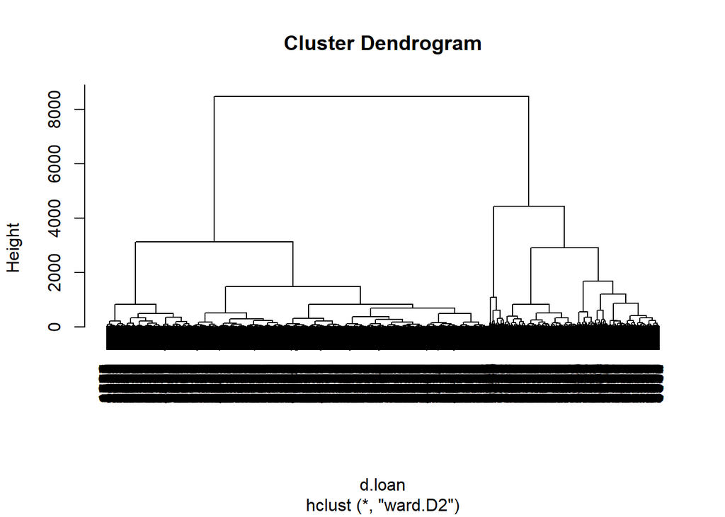

```r
d.loan <- dist(x=LoanP.data[,-c(1,5)], method = "euclidean")
clus1 <- hclust(d.loan, method = "ward.D2")
plot(clus1, labels = as.character(LoanP.data[,1]))
```

Observation Dendogram shows cluster groupings of 3 to 4. Based on the Business input one can draw a line and go with number of clusters.

2.2 Apply Hierarchical Clustering Algorithm - Try with scaled data

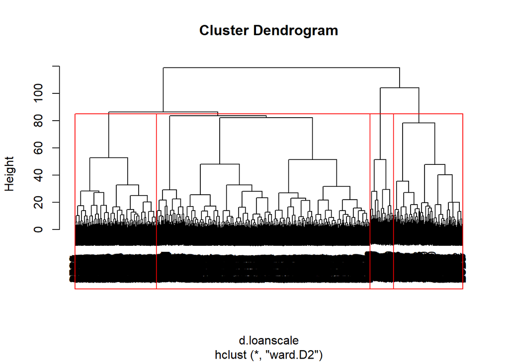

```r
d.loanscale <- dist(x=LoanP.scaled, method = "euclidean")
clus2 <- hclust(d.loanscale, method = "ward.D2")
plot(clus2, labels = as.character(LoanP.data[,1]))
rect.hclust(clus2, k=4, border="red")
```

Observation Dendogram again shows cluster groping of 3 to 4. We will go with 4 clusters for this usecase

Profiling the clusters with assumption of 4 clusters

```r
LoanP.data$hClusters <- cutree(clus2, k=4)
aggr = aggregate(LoanP.data[,-c(1,5,15)],list(LoanP.data$hClusters),mean)
hclus.profile = data.frame( Cluster=aggr[,1],
                            Freq=as.vector(table(LoanP.data$hClusters)),
                            aggr[,-1])
print(hclus.profile)
```

```
##   Cluster Freq Age..in.years. Experience..in.years. Income..in.K.month.
## 1       1 2754       45.17829              19.90487            55.20044
## 2       2 1052       45.63213              20.39544            60.06179
## 3       3  892       45.36323              20.30381           136.85874
## 4       4  302       45.70199              20.57285           104.58940
##   Family.members    CCAvg Education  Mortgage Personal.Loan
## 1       2.524328 1.389666  1.978214  45.19245     0.0000000
## 2       2.441065 1.420162  1.884030  38.67490     0.0000000
## 3       1.889013 3.922747  1.561659 100.29821     0.3811659
## 4       2.443709 2.878974  1.927152  92.32450     0.4635762
##   Securities.Account CD.Account    Online CreditCard
## 1         0.13289760          0 0.5784314 0.01633987
## 2         0.00000000          0 0.5760456 1.00000000
## 3         0.01008969          0 0.5627803 0.14910314
## 4         0.48675497          1 0.9370861 0.79470199
```

Observation Cluster 1 - These are low income customers never opted for Personal Loan, with Age and Experience on the lower side, medium family size, have Mortgage and vary rarely using Bank’s credit card. C Lose to 55% of customers falls into this category.

Cluster 2 - These are medium income credit card use customers never opted for Personal Loan and never opted for securities account

Cluster 3 - These are very high income customers with a very high Mortgage and some population opted for personal Loan and have high credit card spending

Cluster 4 - These are high income high mortgage customers with high population of opting for personal loan and a heavy use of Internet banking usage

2.2 Now Let’s try with Kmeans Clustering Algorithm

wssplot and nbclust used to identify potential clusters.

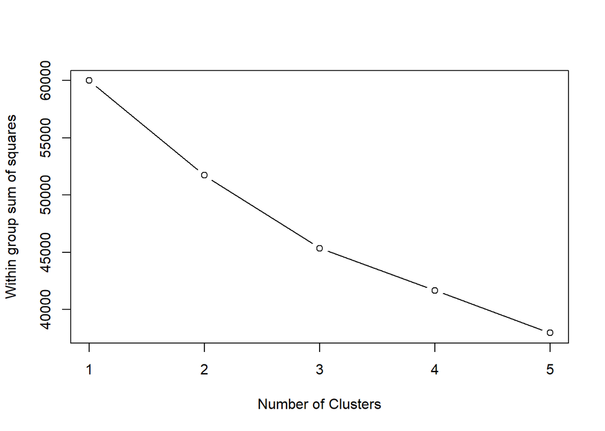

```r
wssplot <- function(data,nc){
  wss <- (nrow(data)-1)*sum(apply(data,2,var))
  for (i in 2:nc) {
    wss[i] <- sum(kmeans(data,centers=i)$withinss)}
  plot(1:nc,wss,type="b",xlab="Number of Clusters",
       ylab="Within group sum of squares")}

wssplot(LoanP.scaled,nc=5)
```

Let’s Identifying the optimal number of clusters using nbclust

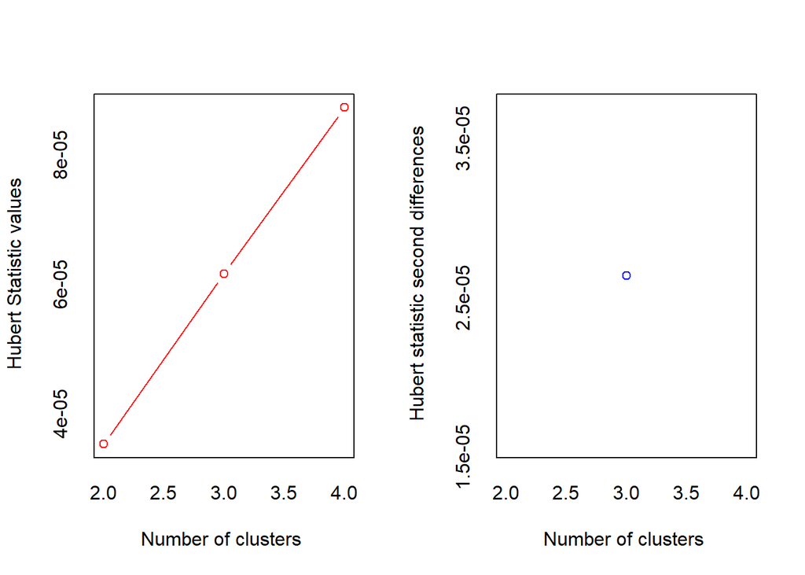

```
## *** : The Hubert index is a graphical method of determining the number of clusters.
##                 In the plot of Hubert index, we seek a significant knee that corresponds to a
##                 significant increase of the value of the measure i.e the significant peak in Hubert
##                 index second differences plot.
##
```

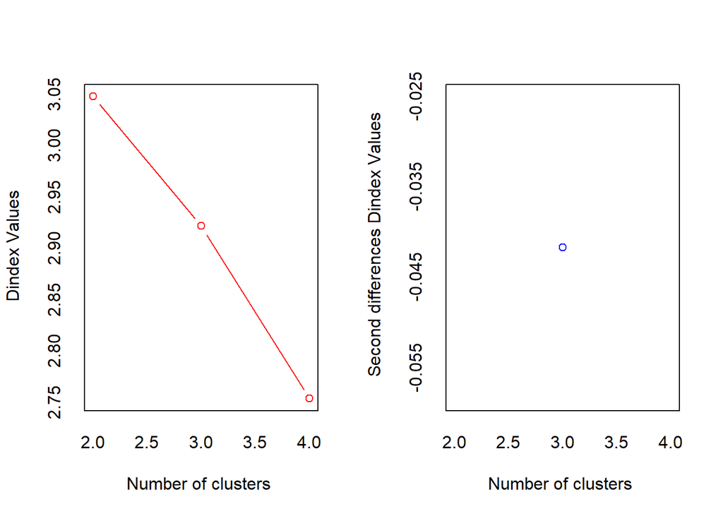

```
## *** : The D index is a graphical method of determining the number of clusters.
##                 In the plot of D index, we seek a significant knee (the significant peak in Dindex
##                 second differences plot) that corresponds to a significant increase of the value of
##                 the measure.
##
## * Among all indices:
## * 5 proposed 2 as the best number of clusters
## * 6 proposed 3 as the best number of clusters
## * 12 proposed 4 as the best number of clusters
##
##                    ***** Conclusion *****
##
## * According to the majority rule, the best number of clusters is  4
##
##
```

```r
library(NbClust)
nc <- NbClust(LoanP.scaled, min.nc=2, max.nc=4, method="kmeans")
```

```r
table(nc$Best.n[1,])
```

```
##
##  0  1  2  3  4
##  2  1  5  6 12
```

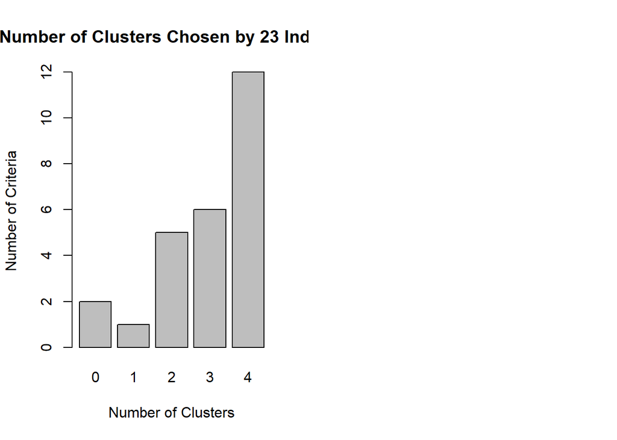

```r
barplot(table(nc$Best.n[1,]),
        xlab="Number of Clusters", ylab="Number of Criteria",
        main="Number of Clusters Chosen by 23 Indices")
```

Observation nbclust recommended as below * Among all indices:  
* 5 proposed 2 as the best number of clusters * 6 proposed 3 as the best number of clusters * 12 proposed 4 as the best number of clusters **** Conclusion *****  
* According to the majority rule, the best number of clusters is 4 nbclust recommended 4 clusters

Run Kmeans with “centers” as number of clusters

```r
kmeans.clus = kmeans(x=LoanP.scaled, centers = 4, nstart = 25)
```

Plot the clusters

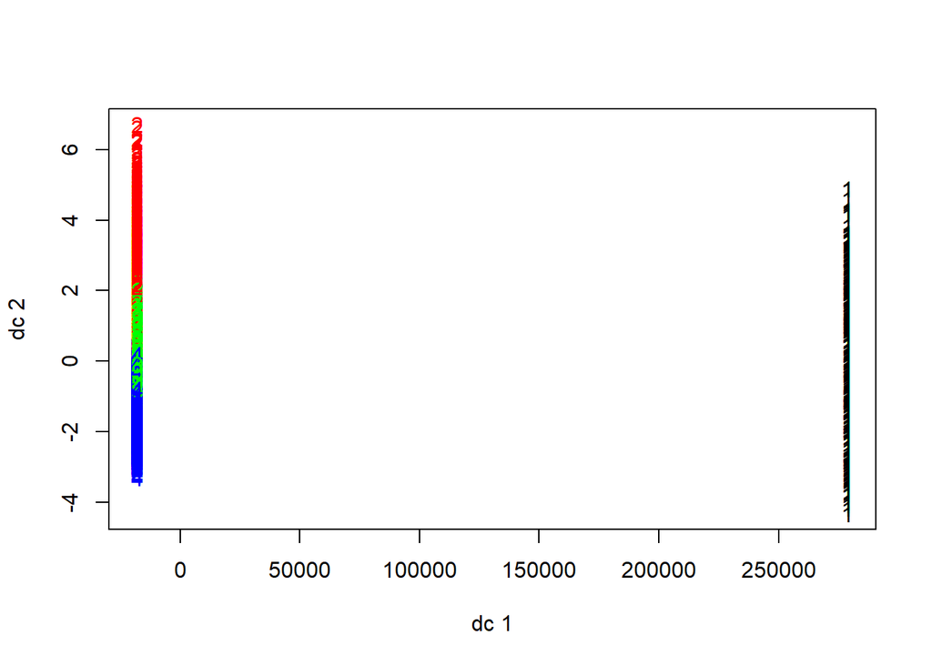

```r
library(fpc)
plotcluster(LoanP.scaled, kmeans.clus$cluster)
```

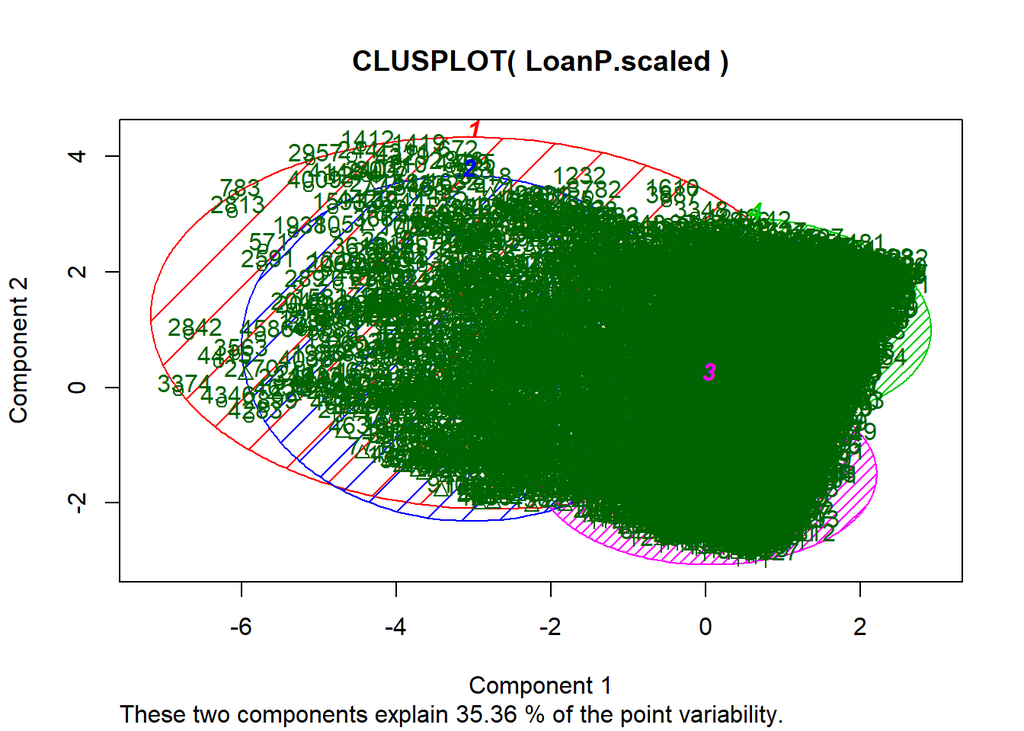

```r
# More complex
library(cluster)
clusplot(LoanP.scaled, kmeans.clus$cluster,
         color=TRUE, shade=TRUE, labels=2, lines=1)
```

profiling the clusters

```r
LoanP.data$kClusters <- kmeans.clus$cluster
aggr = aggregate(LoanP.data[,-c(1,5, 15)],list(LoanP.data$kClusters),mean)
kclus.profile <- data.frame( Cluster=aggr[,1],
                            Freq=as.vector(table(LoanP.data$kClusters)),
                            aggr[,-1])
str(kclus.profile)
```

```
## 'data.frame':    4 obs. of  15 variables:
##  $ Cluster              : int  1 2 3 4
##  $ Freq                 : int  302 750 1920 2028
##  $ Age..in.years.       : num  45.7 43.5 35.3 55.5
##  $ Experience..in.years.: num  20.6 18.5 10.1 30.2
##  $ Income..in.K.month.  : num  104.6 145.8 58.5 57
##  $ Family.members       : num  2.44 1.99 2.57 2.36
##  $ CCAvg                : num  2.88 4.56 1.38 1.36
##  $ Education            : num  1.93 1.59 1.93 1.93
##  $ Mortgage             : num  92.3 94.6 46.9 46.1
##  $ Personal.Loan        : num  0.463576 0.452 0 0.000493
##  $ Securities.Account   : num  0.4868 0.0493 0.0911 0.0804
##  $ CD.Account           : num  1 0 0 0
##  $ Online               : num  0.937 0.528 0.566 0.601
##  $ CreditCard           : num  0.795 0.205 0.266 0.279
##  $ kClusters            : num  1 2 3 4
```

```r
print(kclus.profile)
```

```
##   Cluster Freq Age..in.years. Experience..in.years. Income..in.K.month.
## 1       1  302       45.70199              20.57285           104.58940
## 2       2  750       43.46933              18.47467           145.81333
## 3       3 1920       35.30417              10.08958            58.51198
## 4       4 2028       55.47535              30.15631            56.99310
##   Family.members    CCAvg Education Mortgage Personal.Loan
## 1       2.443709 2.878974  1.927152 92.32450  0.4635761589
## 2       1.990667 4.562640  1.588000 94.61467  0.4520000000
## 3       2.567188 1.379406  1.932813 46.91615  0.0000000000
## 4       2.358481 1.355917  1.933432 46.14004  0.0004930966
##   Securities.Account CD.Account    Online CreditCard kClusters
## 1         0.48675497          1 0.9370861  0.7947020         1
## 2         0.04933333          0 0.5280000  0.2053333         2
## 3         0.09114583          0 0.5661458  0.2656250         3
## 4         0.08037475          0 0.6005917  0.2790927         4
```

Observation Again similar grouping what we got from Hierarchical clustering with minor changes.

Cluster 2 - These are very high income customers with a very high Mortgage and half of the population opted for personal Loan and have high credit card spending. 15% of total customers are mapped to Cluster2

While both Clustering Algorithms arrived at 4 Clusters, K means categorization is better.

#### Section 3/4 Applying CART technique

CART is a decision tree based model. First split input dataset to Test Vs Train data using random technique

```r
smp_size = floor(0.75*nrow(LoanP.data))
smp_size
```

```
## [1] 3750
```

```r
set.seed(123)
train_ind = sample(seq_len(nrow(LoanPcartrandom.data)),size = smp_size)
LoanP.train = LoanPcartrandom.data[train_ind,]
LoanP.test= LoanPcartrandom.data[-train_ind,]
Loanrandom.train = LoanP.train
Loanrandom.test = LoanP.test
Loancv.train = LoanP.train
Loancv.test = LoanP.test
str(LoanP.test)
```

```
## 'data.frame':    1250 obs. of  14 variables:
##  $ ID                   : int  4 6 8 9 23 24 38 47 48 50 ...
##  $ Age..in.years.       : int  35 37 50 35 29 44 51 39 37 40 ...
##  $ Experience..in.years.: num  9 13 24 10 5 18 25 14 12 16 ...
##  $ Income..in.K.month.  : int  100 29 22 81 62 43 71 43 194 49 ...
##  $ ZIP.Code             : int  94112 92121 93943 90089 90277 91320 95814 95014 91380 92373 ...
##  $ Family.members       : num  1 4 1 3 1 2 1 3 4 1 ...
##  $ CCAvg                : num  2.7 0.4 0.3 0.6 1.2 0.7 1.4 0.7 0.2 1.8 ...
##  $ Education            : int  2 2 3 2 1 1 3 2 3 1 ...
##  $ Mortgage             : int  0 155 0 104 260 163 198 153 211 0 ...
##  $ Personal.Loan        : int  0 0 0 0 0 0 0 0 1 0 ...
##  $ Securities.Account   : int  0 0 0 0 0 1 0 0 1 0 ...
##  $ CD.Account           : int  0 0 0 0 0 0 0 0 1 0 ...
##  $ Online               : int  0 1 0 1 1 0 0 1 1 0 ...
##  $ CreditCard           : int  0 0 1 0 0 0 0 0 1 1 ...
```

```r
str(LoanP.train)
```

```
## 'data.frame':    3750 obs. of  14 variables:
##  $ ID                   : int  2463 2511 2227 526 4291 2986 1842 1142 3371 3446 ...
##  $ Age..in.years.       : int  52 62 25 64 66 48 42 32 39 37 ...
##  $ Experience..in.years.: num  28 38 1 38 42 23 17 7 13 13 ...
##  $ Income..in.K.month.  : int  23 52 98 79 95 63 91 143 59 38 ...
##  $ ZIP.Code             : int  95828 95616 90717 94024 94596 94606 94583 91365 90033 94701 ...
##  $ Family.members       : num  3 4 1 2 2 4 1 3 3 1 ...
##  $ CCAvg                : num  0.4 1.3 5.4 2.8 0 3.6 0.1 2.9 0.9 1.5 ...
##  $ Education            : int  1 2 1 1 3 3 2 3 3 2 ...
##  $ Mortgage             : int  0 0 0 179 0 0 199 0 199 116 ...
##  $ Personal.Loan        : int  0 0 0 0 0 0 0 1 0 0 ...
##  $ Securities.Account   : int  0 0 0 0 0 0 0 0 1 0 ...
##  $ CD.Account           : int  0 0 0 0 0 0 0 0 0 0 ...
##  $ Online               : int  1 1 1 0 1 0 1 1 1 0 ...
##  $ CreditCard           : int  0 1 0 0 0 0 1 0 0 1 ...
```

```r
str(Loanrandom.train)
```

```
## 'data.frame':    3750 obs. of  14 variables:
##  $ ID                   : int  2463 2511 2227 526 4291 2986 1842 1142 3371 3446 ...
##  $ Age..in.years.       : int  52 62 25 64 66 48 42 32 39 37 ...
##  $ Experience..in.years.: num  28 38 1 38 42 23 17 7 13 13 ...
##  $ Income..in.K.month.  : int  23 52 98 79 95 63 91 143 59 38 ...
##  $ ZIP.Code             : int  95828 95616 90717 94024 94596 94606 94583 91365 90033 94701 ...
##  $ Family.members       : num  3 4 1 2 2 4 1 3 3 1 ...
##  $ CCAvg                : num  0.4 1.3 5.4 2.8 0 3.6 0.1 2.9 0.9 1.5 ...
##  $ Education            : int  1 2 1 1 3 3 2 3 3 2 ...
##  $ Mortgage             : int  0 0 0 179 0 0 199 0 199 116 ...
##  $ Personal.Loan        : int  0 0 0 0 0 0 0 1 0 0 ...
##  $ Securities.Account   : int  0 0 0 0 0 0 0 0 1 0 ...
##  $ CD.Account           : int  0 0 0 0 0 0 0 0 0 0 ...
##  $ Online               : int  1 1 1 0 1 0 1 1 1 0 ...
##  $ CreditCard           : int  0 1 0 0 0 0 1 0 0 1 ...
```

```r
str(Loanrandom.test)
```

```
## 'data.frame':    1250 obs. of  14 variables:
##  $ ID                   : int  4 6 8 9 23 24 38 47 48 50 ...
##  $ Age..in.years.       : int  35 37 50 35 29 44 51 39 37 40 ...
##  $ Experience..in.years.: num  9 13 24 10 5 18 25 14 12 16 ...
##  $ Income..in.K.month.  : int  100 29 22 81 62 43 71 43 194 49 ...
##  $ ZIP.Code             : int  94112 92121 93943 90089 90277 91320 95814 95014 91380 92373 ...
##  $ Family.members       : num  1 4 1 3 1 2 1 3 4 1 ...
##  $ CCAvg                : num  2.7 0.4 0.3 0.6 1.2 0.7 1.4 0.7 0.2 1.8 ...
##  $ Education            : int  2 2 3 2 1 1 3 2 3 1 ...
##  $ Mortgage             : int  0 155 0 104 260 163 198 153 211 0 ...
##  $ Personal.Loan        : int  0 0 0 0 0 0 0 0 1 0 ...
##  $ Securities.Account   : int  0 0 0 0 0 1 0 0 1 0 ...
##  $ CD.Account           : int  0 0 0 0 0 0 0 0 1 0 ...
##  $ Online               : int  0 1 0 1 1 0 0 1 1 0 ...
##  $ CreditCard           : int  0 0 1 0 0 0 0 0 1 1 ...
```

Observations Train dataset created with 3750 observations Test Dataset created with 1250 observations Making same copy for Random forest tests. One for Random Forest and one for Random Forest Cross validation. This will help in comparison between CART and Random Forest Models.

set the control parameter inputs for rpart, call rpart to build the tree and then plot the tree

```r
library(rpart)
library(rpart.plot)
r.ctrl = rpart.control(minsplit=100, minbucket = 10, cp = 0, xval = 10)
m1 <- rpart(formula = LoanP.train$Personal.Loan ~ ., data =  LoanP.train[,-c(1,5)], method = "class", control = r.ctrl)
m1
```

```
## n= 3750
##
## node), split, n, loss, yval, (yprob)
##       * denotes terminal node
##
##  1) root 3750 354 0 (0.905600000 0.094400000)
##    2) Income..in.K.month.< 100.5 2833  27 0 (0.990469467 0.009530533) *
##    3) Income..in.K.month.>=100.5 917 327 0 (0.643402399 0.356597601)
##      6) Education< 1.5 581  63 0 (0.891566265 0.108433735)
##       12) Family.members< 2.5 508   3 0 (0.994094488 0.005905512) *
##       13) Family.members>=2.5 73  13 1 (0.178082192 0.821917808) *
##      7) Education>=1.5 336  72 1 (0.214285714 0.785714286)
##       14) Income..in.K.month.< 116.5 109  37 0 (0.660550459 0.339449541)
##         28) CCAvg< 2.45 68  10 0 (0.852941176 0.147058824) *
##         29) CCAvg>=2.45 41  14 1 (0.341463415 0.658536585) *
##       15) Income..in.K.month.>=116.5 227   0 1 (0.000000000 1.000000000) *
```

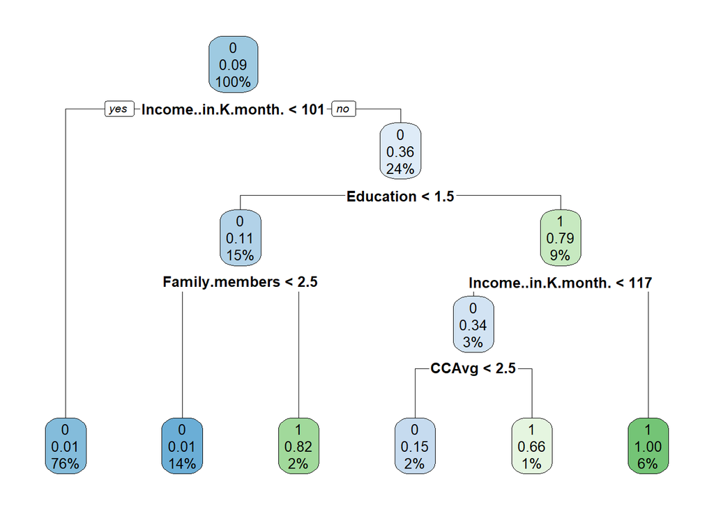

```r
rpart.plot(m1)
```

Find how the tree performs and derive cp value. The following table shall show CP values in the tree only if there is a significant jump in the error. Look at xerror which shows the error factor using cross validated dated (K times)

```r
printcp(m1)
```

```
##
## Classification tree:
## rpart(formula = LoanP.train$Personal.Loan ~ ., data = LoanP.train[,
##     -c(1, 5)], method = "class", control = r.ctrl)
##
## Variables actually used in tree construction:
## [1] CCAvg               Education           Family.members
## [4] Income..in.K.month.
##
## Root node error: 354/3750 = 0.0944
##
## n= 3750
##
##         CP nsplit rel error  xerror     xstd
## 1 0.271186      0   1.00000 1.00000 0.050579
## 2 0.132768      2   0.45763 0.45763 0.035169
## 3 0.098870      3   0.32486 0.32486 0.029825
## 4 0.036723      4   0.22599 0.25706 0.026618
## 5 0.000000      5   0.18927 0.20621 0.023900
```

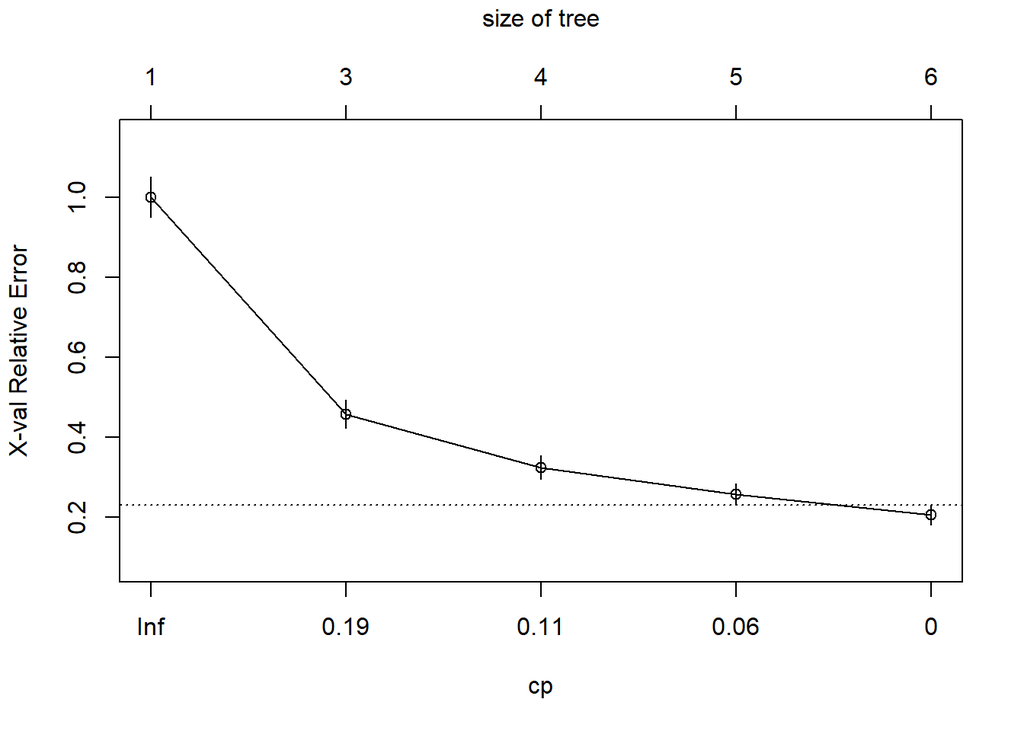

```r
plotcp(m1)
```

As X error reducing trend and ends at last observation we will take CO as 0.0000 Use this as cP value and prune the tree

```r
ptree<- prune(m1, cp= 0.0000 ,"CP")
printcp(ptree)
```

```
##
## Classification tree:
## rpart(formula = LoanP.train$Personal.Loan ~ ., data = LoanP.train[,
##     -c(1, 5)], method = "class", control = r.ctrl)
##
## Variables actually used in tree construction:
## [1] CCAvg               Education           Family.members
## [4] Income..in.K.month.
##
## Root node error: 354/3750 = 0.0944
##
## n= 3750
##
##         CP nsplit rel error  xerror     xstd
## 1 0.271186      0   1.00000 1.00000 0.050579
## 2 0.132768      2   0.45763 0.45763 0.035169
## 3 0.098870      3   0.32486 0.32486 0.029825
## 4 0.036723      4   0.22599 0.25706 0.026618
## 5 0.000000      5   0.18927 0.20621 0.023900
```

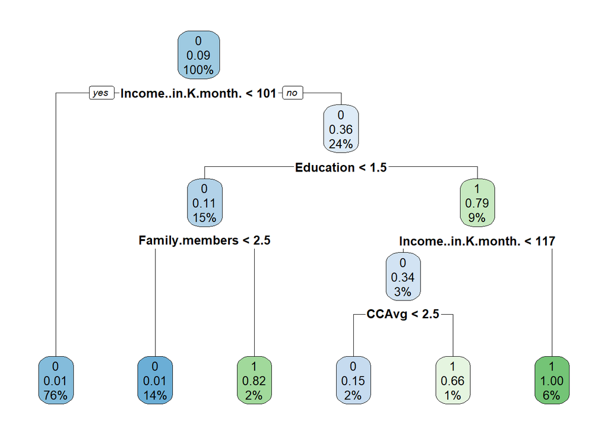

```r
rpart.plot(ptree)
```

Add Predict class and score attribute to Train dataset

```r
## Scoring syntax
LoanP.train$predict.class <- predict(ptree, LoanP.train, type="class")
LoanP.train$predict.score <- predict(ptree, LoanP.train)

head(LoanP.train)
```

```
##        ID Age..in.years. Experience..in.years. Income..in.K.month.
## 2463 2463             52                    28                  23
## 2511 2511             62                    38                  52
## 2227 2227             25                     1                  98
## 526   526             64                    38                  79
## 4291 4291             66                    42                  95
## 2986 2986             48                    23                  63
##      ZIP.Code Family.members CCAvg Education Mortgage Personal.Loan
## 2463    95828              3   0.4         1        0             0
## 2511    95616              4   1.3         2        0             0
## 2227    90717              1   5.4         1        0             0
## 526     94024              2   2.8         1      179             0
## 4291    94596              2   0.0         3        0             0
## 2986    94606              4   3.6         3        0             0
##      Securities.Account CD.Account Online CreditCard predict.class
## 2463                  0          0      1          0             0
## 2511                  0          0      1          1             0
## 2227                  0          0      1          0             0
## 526                   0          0      0          0             0
## 4291                  0          0      1          0             0
## 2986                  0          0      0          0             0
##      predict.score.0 predict.score.1
## 2463     0.990469467     0.009530533
## 2511     0.990469467     0.009530533
## 2227     0.990469467     0.009530533
## 526      0.990469467     0.009530533
## 4291     0.990469467     0.009530533
## 2986     0.990469467     0.009530533
```

Observation Higher the predict score mapping is classified to class 0 this is because we have large number of observations with personal loan as 0

Now Let’s Predict for Personal Loan on Test data.

Predicting the Probabilities and the prediction class for the test data.

```r
LoanP.test$predict.class <- predict(ptree,LoanP.test, type="class")
LoanP.test$predict.score <- predict(ptree,LoanP.test, type="prob")
head(LoanP.test)
```

```
##    ID Age..in.years. Experience..in.years. Income..in.K.month. ZIP.Code
## 4   4             35                     9                 100    94112
## 6   6             37                    13                  29    92121
## 8   8             50                    24                  22    93943
## 9   9             35                    10                  81    90089
## 23 23             29                     5                  62    90277
## 24 24             44                    18                  43    91320
##    Family.members CCAvg Education Mortgage Personal.Loan
## 4               1   2.7         2        0             0
## 6               4   0.4         2      155             0
## 8               1   0.3         3        0             0
## 9               3   0.6         2      104             0
## 23              1   1.2         1      260             0
## 24              2   0.7         1      163             0
##    Securities.Account CD.Account Online CreditCard predict.class
## 4                   0          0      0          0             0
## 6                   0          0      1          0             0
## 8                   0          0      0          1             0
## 9                   0          0      1          0             0
## 23                  0          0      1          0             0
## 24                  1          0      0          0             0
##    predict.score.0 predict.score.1
## 4      0.990469467     0.009530533
## 6      0.990469467     0.009530533
## 8      0.990469467     0.009530533
## 9      0.990469467     0.009530533
## 23     0.990469467     0.009530533
## 24     0.990469467     0.009530533
```

```r
MLmetrics::AUC(LoanP.test$predict.score[,2],
                LoanP.test$Personal.Loan)
```

```
## [1] 0.9458001
```

Observation AUC is 0.9458001 which is good

Now Let’s compute the Gini

```r
library(ineq)
ginicart = ineq(LoanP.test$predict.score[,2], type="Gini")
ginicart
```

```
## [1] 0.8278681
```

Observation - gini value 0.8278681

AUC and KS computation

```r
library(ROCR)
```

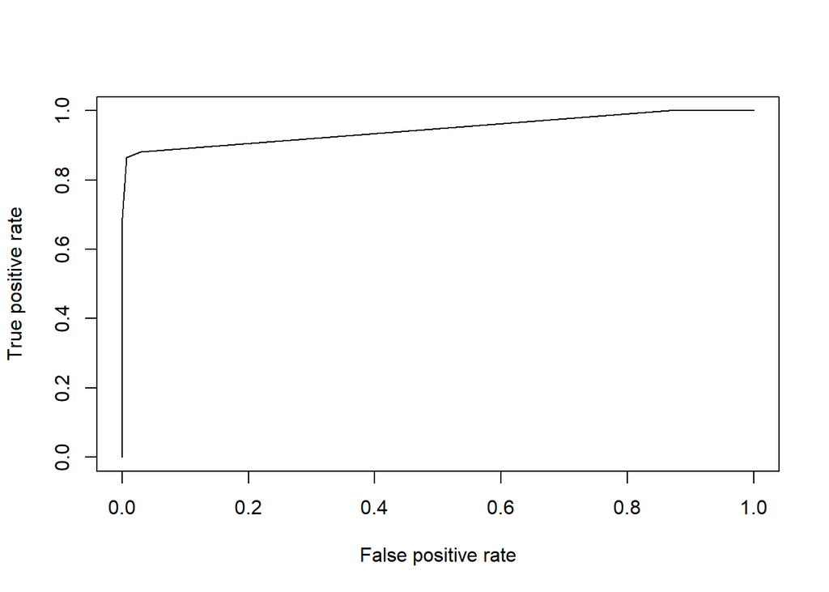

```r
predc = prediction(LoanP.test$predict.score[,2], LoanP.test$Personal.Loan)
perfc = performance(predc, "tpr", "fpr")
plot(perfc)
```

```r
KScart = max(attr(perfc, 'y.values')[[1]]-attr(perfc, 'x.values')[[1]])
auccart = performance(predc, 'auc');
auccart = as.numeric(auccart@y.values)
auccart
```

```
## [1] 0.9458001
```

```r
KScart
```

```
## [1] 0.8579619
```

observation auc 0.9458001 KS 0.8579619

Print Model performance statistics

```r
with(LoanP.test, table(LoanP.test$Personal.Loan, LoanP.test$predict.class))
```

```
##
##        0    1
##   0 1116    8
##   1   17  109
```

```r
auccart
```

```
## [1] 0.9458001
```

```r
KScart
```

```
## [1] 0.8579619
```

```r
ginicart
```

```
## [1] 0.8278681
```

Observation Model Performance stats

Confusion Matrix 0 1 0 1116 8 1 17 109

Above captures the confusion matrix results. Model predicted 1116 Negatives as Negatives and 8 wrong Negatives Model predicted 109 Positives as Positives and 17 wrong positives

Sensitivity = True Positive/Total positive = 109/126 = 86.50% specificity - True Negatives/Total Negatives = 1116/1124 = 99.28% Accuracy = True Positives + True Negatives/Total observations = 1116+109/1250 = 98%

Model predicted 98% observations correctly. Model was able to predict large Negatives correctly as observations in Train dataset as larger Negative values i.e. 0

CART model was able to predict large population correctly with an exception 25 observations where it predicted wrongly.

AUC - 0.9458001 KS - 0.8579619 gini - 0.8278681

#### Overall CART Model Performance is good. We will try next Random Forest and then compare two models

#### Section 3/4 Applying Random Forest technique

we will use Loanrandom.train and Loanrandom.test datasets created in last step (CART). This is done as we would like same data to be fed to both Models for comparison.

Build Random forest

```r
library(randomForest)
RF = randomForest(as.factor(Loanrandom.train$Personal.Loan) ~ ., data = Loanrandom.train[,-1],
                   ntree=501, mtry = 4, nodesize =10, importance=TRUE)
print(RF)
```

```
##
## Call:
##  randomForest(formula = as.factor(Loanrandom.train$Personal.Loan) ~      ., data = Loanrandom.train[, -1], ntree = 501, mtry = 4,      nodesize = 10, importance = TRUE)
##                Type of random forest: classification
##                      Number of trees: 501
## No. of variables tried at each split: 4
##
##         OOB estimate of  error rate: 1.47%
## Confusion matrix:
##      0   1 class.error
## 0 3381  15 0.004416961
## 1   40 314 0.112994350
```

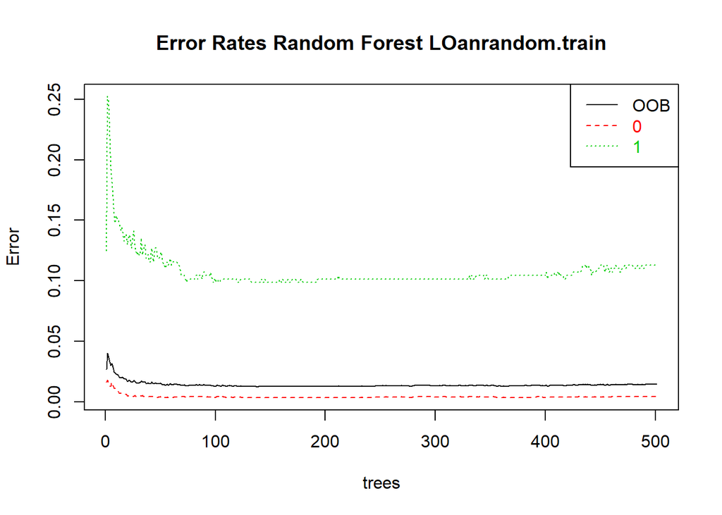

```r
plot(RF, main="")
legend("topright", c("OOB", "0", "1"), text.col=1:6, lty=1:3, col=1:3)
title(main="Error Rates Random Forest LOanrandom.train")
```

List the importance of the variables.Highlight both the rows together and run the code

```r
RF$err.rate
```

[output not shown]

[output cut: 487 more lines]

```r
impVar <- round(randomForest::importance(RF), 2)
impVar[order(impVar[,3], decreasing=TRUE),]
```

```
##                            0     1 MeanDecreaseAccuracy MeanDecreaseGini
## Income..in.K.month.   120.94 90.06               129.70           205.39
## Education             124.87 75.41               128.27           136.64
## Family.members         85.09 46.17                84.55            74.82
## CCAvg                  27.67 29.91                31.99            77.56
## CD.Account             14.67 10.81                17.69            34.23
## Age..in.years.         12.98  0.83                13.24            11.99
## Experience..in.years.  11.92  0.77                12.07            11.08
## Mortgage               10.56 -1.44                 9.84            13.39
## CreditCard              7.55  3.57                 8.60             2.25
## Securities.Account      1.47  5.64                 5.38             1.38
## Online                  2.10  2.37                 3.38             1.57
## ZIP.Code               -1.33  1.92                 0.06            10.08
```

```
## mtry = 4  OOB error = 1.6%
## Searching left ...
## mtry = 3     OOB error = 1.65%
## -0.03333333 1e-04
## Searching right ...
## mtry = 6     OOB error = 1.33%
## 0.1666667 1e-04
## mtry = 9     OOB error = 1.57%
## -0.18 1e-04
```

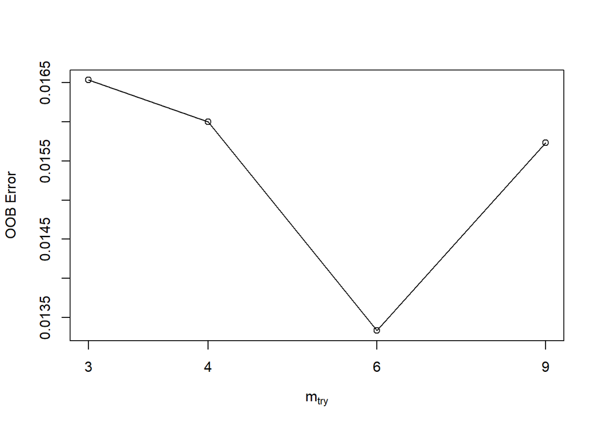

```r
## Tuning Random Forest
tRF <- tuneRF(x = Loanrandom.train[,-c(1,10)],
              y=as.factor(Loanrandom.train$Personal.Loan),
              mtryStart = 4,
              ntreeTry=100,
              stepFactor = 1.5,
              improve = 0.0001,
              trace=TRUE,
              plot = TRUE,
              doBest = TRUE,
              nodesize = 10,
              importance=TRUE
)
```